```python
import pyspark
from pyspark.sql import SQLContext, functions as F, Row
from pyspark.sql.functions import udf, split
from pyspark.sql.types import StringType, IntegerType, StructField, StructType, ArrayType
from pyspark.ml.feature import StopWordsRemover, CountVectorizer, RegexTokenizer, IDF
from pyspark.ml import Pipeline
from pyspark.ml.classification import LogisticRegression

from langdetect import detect
from langdetect.lang_detect_exception import LangDetectException
import seaborn as sns
from nltk.corpus import stopwords
import spacy
import os
```

```python
conf = pyspark.SparkConf().setAppName('BDS').setMaster('spark://192.168.56.1:7077')
sc = pyspark.SparkContext(conf=conf)
sql_sc = SQLContext(sc)
```

# Book review data

When doing some research online, many datasets for English tweet sentiment analysis are available. However, Dutch datasets are not.

Since labeling tweets manually will take too much time, we chose the next best alternative. A dataset containing book review data, each review is labeled as negative (0) or positive (1). We think this could be a suitable dataset to train or machine learning model on, because when you compare both the reviews and tweets, they are actually quite comparable.

The dataset is ~74MB compressed and can be downloaded from here: **[110k Dutch Book Reviews Dataset](https://github.com/benjaminvdb/110kDBRD/releases/download/v2.0/110kDBRD_v2.tgz)**

```python
# We merged both test and train sets, because we will be using a random split later on for validation and testing
REVIEWS_POSITIVE = './book_reviews/pos/'
REVIEWS_NEGATIVE = './book_reviews/neg/'
```

```python
# Load the dataets and convert them to dataframes
row = Row("text")
positive = sc.wholeTextFiles(REVIEWS_POSITIVE).map(lambda x: x[1]).map(row).toDF().withColumn('label', F.lit(1))
negative = sc.wholeTextFiles(REVIEWS_NEGATIVE).map(lambda x: x[1]).map(row).toDF().withColumn('label', F.lit(0))
book_data = positive.union(negative)
book_data.show()
```

```
+--------------------+-----+
|                text|label|
+--------------------+-----+
|Het Brussel-syndr...|    1|
|Super om te lezen...|    1|
|Dolf uit Amstelve...|    1|
|Bijna iedereen wi...|    1|
|De verzamelaar va...|    1|
|Miss peregrine's ...|    1|
|Jitzak, de roman ...|    1|
|Was benieuwd naar...|    1|
|Al voor verschijn...|    1|
|Deze jongen kan s...|    1|
|Dit is voor mij h...|    1|
|Hoe verder ik in ...|    1|
|In de nacht van 2...|    1|
|Wat een serie! Ma...|    1|
|Geeft een andere ...|    1|
|Breek mijn hart n...|    1|
|Wellicht komt het...|    1|
|Een van de beste ...|    1|
|Heerlijk luguber ...|    1|
|Geloof je wat je ...|    1|
+--------------------+-----+
only showing top 20 rows
```

# Exploring the data

We need to check if we have enough samples and if the labels are equally represented, we do this by using a countplot over the different labels in the datafram

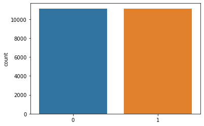

```python
sns.countplot(x = book_data.rdd.map(lambda x: x[1]).collect())
```

# Create the spark pipeline and extract features

To process the data we will be using Spark and its Machine Learning Library.

```python
# Turn strings into arrays of words
tokenizer = RegexTokenizer().setGaps(False)\
  .setPattern("\\p{L}+")\
  .setInputCol("text")\
  .setOutputCol("words")
```

```python
# Remove dutch stopwords
stopw = stopwords.words('dutch')
sw_filter = StopWordsRemover()\
  .setStopWords(stopw)\
  .setCaseSensitive(False)\
  .setInputCol("words")\
  .setOutputCol("filtered")
```

```python
# We will remove words that appear in 5 docs or less
cv = CountVectorizer(minTF=1., minDF=5., vocabSize=2**17)\
  .setInputCol("filtered")\
  .setOutputCol("tf")
```

```python
# we now create a pipelined transformer
cv_pipeline = Pipeline(stages=[tokenizer, sw_filter, cv]).fit(book_data)
```

```python
# now we can make the transformation between the raw text and the counts
cv_pipeline.transform(book_data).show(5)
```

```
+--------------------+-----+--------------------+--------------------+--------------------+
|                text|label|               words|            filtered|                  tf|
+--------------------+-----+--------------------+--------------------+--------------------+
|Het Brussel-syndr...|    1|[het, brussel, sy...|[brussel, syndroo...|(28751,[0,2,7,10,...|
|Super om te lezen...|    1|[super, om, te, l...|[super, lezen, le...|(28751,[3,6,229,9...|
|Dolf uit Amstelve...|    1|[dolf, uit, amste...|[dolf, amstelveen...|(28751,[0,9,21,23...|
|Bijna iedereen wi...|    1|[bijna, iedereen,...|[bijna, iedereen,...|(28751,[0,2,6,7,8...|
|De verzamelaar va...|    1|[de, verzamelaar,...|[verzamelaar, joh...|(28751,[0,3,22,24...|
+--------------------+-----+--------------------+--------------------+--------------------+
only showing top 5 rows
```

```python
idf = IDF().\
    setInputCol('tf').\
    setOutputCol('tfidf')
```

```python
idf_pipeline = Pipeline(stages=[cv_pipeline, idf]).fit(book_data)
```

```python
idf_pipeline.transform(book_data).show(5)
```

```
+--------------------+-----+--------------------+--------------------+--------------------+--------------------+
|                text|label|               words|            filtered|                  tf|               tfidf|
+--------------------+-----+--------------------+--------------------+--------------------+--------------------+
|Het Brussel-syndr...|    1|[het, brussel, sy...|[brussel, syndroo...|(28751,[0,2,7,10,...|(28751,[0,2,7,10,...|
|Super om te lezen...|    1|[super, om, te, l...|[super, lezen, le...|(28751,[3,6,229,9...|(28751,[3,6,229,9...|
|Dolf uit Amstelve...|    1|[dolf, uit, amste...|[dolf, amstelveen...|(28751,[0,9,21,23...|(28751,[0,9,21,23...|
|Bijna iedereen wi...|    1|[bijna, iedereen,...|[bijna, iedereen,...|(28751,[0,2,6,7,8...|(28751,[0,2,6,7,8...|
|De verzamelaar va...|    1|[de, verzamelaar,...|[verzamelaar, joh...|(28751,[0,3,22,24...|(28751,[0,3,22,24...|
+--------------------+-----+--------------------+--------------------+--------------------+--------------------+
only showing top 5 rows
```

```python
tfidf_df = idf_pipeline.transform(book_data)
```

# Estimating Sentiment

To estimate the sentimate, we will be using a random split to create a train, validation and test set. The model we will be using is LogisticRegression, because it is robust, simple and performs quite well.

Note: Loading the model from disk seems to be broken/bugged in recent releases of spark

```python
training_df, validation_df, testing_df = book_data.randomSplit([0.6, 0.3, 0.1], seed=0)
[training_df.count(), validation_df.count(), testing_df.count()]
```

```
[13412, 6597, 2243]
```

```python
lambda_par = 0.02
alpha_par = 0.3

model_file = "./sentiment_model_lr_2"
trained = False
try:
    lr = LogisticRegression.load(model_file)
    print('Loaded pipeline model from disk')
    trained = True
except :
    print('Creating model and saving to disk')
    lr = LogisticRegression().\
        setLabelCol('label').\
        setFeaturesCol('tfidf').\
        setRegParam(lambda_par).\
        setMaxIter(100).\
        setElasticNetParam(alpha_par)

lr_pipeline = Pipeline(stages=[idf_pipeline, lr])
if not trained:
    lr_pipeline = lr_pipeline.fit(training_df)
    lr_pipeline.stages[1].write().overwrite().save(model_file)
```

```
Creating model and saving to disk
```

```python
lr_pipeline.transform(validation_df).\
    select(F.expr('float(prediction = label)').alias('correct')).\
    select(F.avg('correct')).show()
```

```
+------------------+
|      avg(correct)|
+------------------+
|0.8631195998180992|
+------------------+
```

# Applying the model on twitter data

We have gathered a lot of twitter data, there are several sources (the code for gathering the data can be found in the github repository):

- Twitter search API using tweepy
- Twitter stream API using tweepy
- Twitter history using getoldtweets3

For the report we will mainly focus on tweets gathered by the streaming API since the end of April and on historical tweets since the beginning of November 2019 to get a baseline.

To filter tweets on Belgium, we used tweet keywords typical for Belgium and geotag information including:

- belgov
- Covid19Be
- Vakantie
- Exitplan
- Mondmaskers
- ...

```python
TWEET_FOLDER = './tweets'
```

```python
# Get all folders containing tweets to load
folders = [x[0] for x in os.walk(TWEET_FOLDER)]
```

```python
# Load the tweets in a dataframe
tweets = None
for folder in folders:
    df = sql_sc.read.option("header", "true").csv(folders).withColumn('keyword', F.lit(folder))
    if tweets is None:
        tweets = df
    else:
        tweets = tweets.union(df)

tweets.select('keyword').distinct().show(20)
print(tweets.count())
```

```
+--------------------+
|             keyword|
+--------------------+
|./tweets\blijfinu...|
|./tweets\exitstra...|
|./tweets\Covid19B...|
|./tweets\mondmask...|
|./tweets\vakantie...|
|./tweets\belgov_2...|
|            ./tweets|
|     ./tweets\stream|
+--------------------+

3995600
```

```python
# Remove duplicates
tweets.dropDuplicates(['tweet_id','keyword'])
print(tweets.count())
```

```
3995600
```

```python
# To verify, we want to detect the language in the tweet and filter out all languages except dutch
def get_lang(tweet):
    try:
        return detect(tweet)
    except LangDetectException as e:
        return 'unknown'
    except TypeError as e:
        return 'unknown'
```

```python
# Only keep dutch tweets
udf_check_lang = udf(get_lang)
tweets = tweets.withColumn('lang', udf_check_lang('text'))
dutch_tweets = tweets[tweets.lang.isin("nl")]
```

```python
# Generate the predictions based on the trained model
predicted_tweets = lr_pipeline.transform(dutch_tweets).select('text', 'prediction', 'created_at', 'keyword')
```

```python
predicted_tweets_formatted = predicted_tweets.withColumn('created_at', F.substring('created_at', 0, 10))
predicted_tweets_formatted = predicted_tweets_formatted.withColumn('keyword', F.regexp_extract('keyword','[\/]([^\/]+)$',1))
predicted_tweets_formatted.select('keyword','created_at').distinct().show(truncate=False)
```

```
+------------------------------------------+----------+
|keyword                                   |created_at|
+------------------------------------------+----------+
|tweets                                    |2020-05-02|
|tweets\belgov_2019-11-01_2020-05-16       |2020-01-20|
|tweets\belgov_2019-11-01_2020-05-16       |2020-02-13|
|tweets\blijfinuwkot_2019-11-01_2020-05-16 |2020-03-12|
|tweets\Covid19BE_2019-11-01_2020-05-16    |2020-03-25|
|tweets\exitstrategie_2019-11-01_2020-05-16|2020-03-10|
|tweets\exitstrategie_2019-11-01_2020-05-16|2019-11-02|
|tweets\exitstrategie_2019-11-01_2020-05-16|2019-11-14|
|tweets\mondmaskers_2019-11-01_2020-05-16  |2020-03-16|
|tweets\mondmaskers_2019-11-01_2020-05-16  |2020-04-20|
|tweets\stream                             |2020-01-02|
|tweets                                    |2019-11-16|
|tweets\belgov_2019-11-01_2020-05-16       |2020-02-12|
|tweets\blijfinuwkot_2019-11-01_2020-05-16 |2020-05-07|
|tweets\blijfinuwkot_2019-11-01_2020-05-16 |2020-01-04|
|tweets\exitstrategie_2019-11-01_2020-05-16|2020-04-30|
|tweets\exitstrategie_2019-11-01_2020-05-16|2020-03-07|
|tweets\mondmaskers_2019-11-01_2020-05-16  |2020-02-23|
|tweets\stream                             |2020-05-02|
|tweets                                    |2020-03-02|
+------------------------------------------+----------+
only showing top 20 rows
```

```python
# Write the raw data
predicted_tweets_formatted.write.csv('predictions_2_2')
```

```python
# Aggregate the data based on keyword and date
grouped_tweeds_by_day = predicted_tweets_formatted.select('created_at','prediction','keyword')\
    .groupby('created_at','keyword').agg(F.avg('prediction').alias('prediction'),F.count('*').alias('count'))
grouped_tweeds_by_day.show()
```

```
+----------+--------------------+-------------------+-----+
|created_at|             keyword|         prediction|count|
+----------+--------------------+-------------------+-----+
|2020-02-27|tweets\belgov_201...| 0.3767258382642998|  507|
|2020-04-17|tweets\blijfinuwk...|0.36762360446570974| 1254|
|2020-02-11|tweets\blijfinuwk...| 0.4693396226415094|  424|
|2020-03-23|tweets\exitstrate...|0.32973362131029516| 1389|
|2020-05-06|tweets\mondmasker...|  0.333733223363575|26674|
|2020-02-03|              tweets| 0.5012406947890818|  403|
|2020-05-15|tweets\belgov_201...| 0.3333333333333333| 7368|
|2019-12-10|tweets\blijfinuwk...| 0.4641638225255973|  293|
|2020-05-10|tweets\Covid19BE_...| 0.4525870997141555|24139|
|2020-01-13|tweets\exitstrate...| 0.5195402298850574|  435|
|2020-04-14|       tweets\stream|0.36656671664167917| 1334|
|2020-04-17|tweets\vakantie_2...| 0.3661858974358974| 1248|
|2019-12-07|              tweets| 0.4581497797356828|  227|
|2019-12-09|tweets\belgov_201...|0.43346007604562736|  263|
|2019-11-12|tweets\blijfinuwk...| 0.4225352112676056|  284|
|2020-03-18|       tweets\stream| 0.3584474885844749| 1314|
|2020-02-07|tweets\vakantie_2...|0.43213296398891965|  361|
|2019-12-28|              tweets| 0.4613526570048309|  414|
|2020-02-15|              tweets| 0.4609756097560976|  410|
|2020-02-17|              tweets| 0.4547677261613692|  409|
+----------+--------------------+-------------------+-----+
only showing top 20 rows
```

```python
# Since the aggregated data is much smaller, we can load it in memory and write it to a single file by using pandas
grouped_tweeds_by_day_pd = grouped_tweeds_by_day.toPandas()
grouped_tweeds_by_day_pd.head(10)
```

|  | created_at | keyword | prediction | count |
| --- | --- | --- | --- | --- |
| 0 | 2020-02-27 | tweets\belgov_2019-11-01_2020-05-16 | 0.379447 | 506 |
| 1 | 2020-04-17 | tweets\blijfinuwkot_2019-11-01_2020-05-16 | 0.368971 | 1244 |
| 2 | 2020-02-11 | tweets\blijfinuwkot_2019-11-01_2020-05-16 | 0.470309 | 421 |
| 3 | 2020-03-23 | tweets\exitstrategie_2019-11-01_2020-05-16 | 0.327103 | 1391 |
| 4 | 2020-05-06 | tweets\mondmaskers_2019-11-01_2020-05-16 | 0.333571 | 26690 |
| 5 | 2020-02-03 | tweets | 0.500000 | 404 |
| 6 | 2020-05-15 | tweets\belgov_2019-11-01_2020-05-16 | 0.332609 | 7360 |
| 7 | 2019-12-10 | tweets\blijfinuwkot_2019-11-01_2020-05-16 | 0.460751 | 293 |
| 8 | 2020-05-10 | tweets\Covid19BE_2019-11-01_2020-05-16 | 0.452327 | 24133 |
| 9 | 2020-01-13 | tweets\exitstrategie_2019-11-01_2020-05-16 | 0.519362 | 439 |

```python
grouped_tweeds_by_day_pd.to_csv('predictions_aggredated_by_day_2_2.csv')
```

# Data visualisation

To visualize the data, we will be using PowerBi. Due to Ugent restrictions, we are not able to create a live page. However, the powerbi files will be available on github.